# Kelly Farley Portfolio

### Text Data Cleaning

*Driving question*: What are the favorite foods of students, and with what frequency do they occur?

```r
# loading in data about favorite types of food
food <- read.csv("http://reuningscherer.net/S&DS230/data/food.csv",
    header = T)
cuisine <- food$fav_cuisine

cuisine <- as.character(cuisine)  # converted to character
str(unique(cuisine))  # there are 61 unique values in cuisine; to find any significant patterns, let's try to get this down to 10
```

```
##  chr [1:61] "Arabic cuisine" "Italian" "italian" "Turkish " "Italian " ...
```

```r
cuisine2 <- cuisine  # create a backup of data to revert to
cuisine2 <- tolower(cuisine2)  # convert data to lower case
cuisine2 <- gsub(" food", "", cuisine2)  # remove food
cuisine2 <- trimws(cuisine2)  # remove trailing spaces

# remove this and anything that follows
removeThis <- c(" and ", " or ", " cuisine")
for (i in 1:length(removeThis)) {
    cuisine2 <- gsub(paste("(.*)", removeThis[i], ".*", sep = ""),
        "\\1", cuisine2)
}

cuisine2 <- sort(cuisine2)  # down to 39

# instances with same entry but with extra words
searchvec1 <- c("american", "italian", "chinese", "colombian",
    "indian")
for (i in 1:length(searchvec1)) {
    cuisine2 <- gsub(paste(".*", searchvec1[i], ".*", sep = ""),
        searchvec1[i], cuisine2)
}

# recoding specific food as location
searchvec2 <- c("sushi", "orange chicken", "nan", "mac")
replacevec <- c("japanese", "chinese", "indian", "american")
for (i in 1:length(searchvec2)) {
    cuisine2 <- gsub(paste(".*", searchvec2[i], ".*", sep = ""),
        replacevec[i], cuisine2)
}

# combining colombian and hispanic and mexican
hispanicFood <- c("colombian", "hispanic", "mexican")
for (i in 1:length(hispanicFood)) {
    cuisine2 <- gsub(paste(".*", hispanicFood[i], ".*", sep = ""),
        "hispanic", cuisine2)
}

# combining don't have one
allFood <- c("i do not like", "don't have one", "i do not like",
    "all")
for (i in 1:length(allFood)) {
    cuisine2 <- gsub(paste(".*", allFood[i], ".*", sep = ""),
        "none", cuisine2)
}

# specific food item
specificFood <- c("sub sandwhiches", "wraps", "chicken", "lean",
    "seafood", "barbecue")
for (i in 1:length(specificFood)) {
    cuisine2 <- gsub(paste(".*", specificFood[i], ".*", sep = ""),
        "specific", cuisine2)
}

# asian: vietnamese, nepali
asianFood <- c("vietnamese", "nepali")
for (i in 1:length(asianFood)) {
    cuisine2 <- gsub(paste(".*", asianFood[i], ".*", sep = ""),
        "asian", cuisine2)
}

# middle east: arabic, lebanese, turkish
middleFood <- c("arabic", "lebanese", "turkish")
for (i in 1:length(middleFood)) {
    cuisine2 <- gsub(paste(".*", middleFood[i], ".*", sep = ""),
        "mideast", cuisine2)
}

# european: spanish, french, greek
europeanFood <- c("spanish", "french", "greek")
for (i in 1:length(europeanFood)) {
    cuisine2 <- gsub(paste(".*", europeanFood[i], ".*", sep = ""),
        "european", cuisine2)
}

# other with only 1 observation: african, jamacian
otherFood <- c("african", "jamaican")
for (i in 1:length(otherFood)) {
    cuisine2 <- gsub(paste(".*", otherFood[i], ".*", sep = ""),
        "other", cuisine2)
}

# top 15 categories: american, asian, chinese, europe,
# hispanic, indian, italian, japanese, korean, mideast, none,
# other, specific, thai --> we can narrow down the less
# popular asian food categeories a little more (so other than
# chinese); thought about combining european with italian,
# but italian is so popular that it feels bad to generalize
# it!

# combine asian with japanese, korean, thai, indian
combinedAsian <- c("japanese", "korean", "thai", "indian")
for (i in 1:length(combinedAsian)) {
    cuisine2 <- gsub(paste(".*", combinedAsian[i], ".*", sep = ""),
        "asian", cuisine2)
}

# presenting in a table
library(tools)
cuisine2 <- toTitleCase(cuisine2)
finaltab <- table(cuisine2)
percents <- round(finaltab/sum(finaltab) * 100)
names(finaltab) <- paste(names(finaltab), " (", percents, "%)",
    sep = "")
finaltab
```

```
##  American (9%)    Asian (14%)   Chinese (8%)  European (2%) Hispanic (11%)
##             11             18             10              3             14
##  Italian (44%)   Mideast (2%)      None (2%)     Other (2%)  Specific (5%)
##             55              3              3              2              6
```

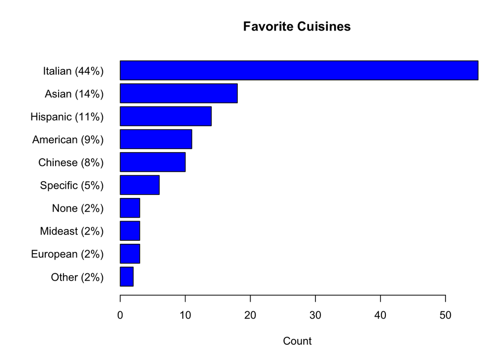

```r
par(mar = c(5, 9, 4, 2), cex = 0.9)
barplot(sort(finaltab), horiz = T, las = 1, col = "blue", main = "Favorite Cuisines",
    xlab = "Count")
```

### Correlation

Below, I clean class survey data to find any patterns of interest in survey responses to probability of taking the class, time spent exercising, time spent on coursework, social liberalness, and economic liberalness.

*Driving question*: Which variables may be correlated and would be interesting to examine together?

```r
# importing data
survey <- read.csv("http://reuningscherer.net/s&ds230/data/class.survey.230.2020.csv",
    header = TRUE, as.is = T)

# cleaning class probability so values between 0 and 1
cleanClassProb <- survey$ClassProb
for (i in 1:length(cleanClassProb)) {
    if (!is.na(cleanClassProb[i])) {
        # don't consider NA values
        if (cleanClassProb[i] > 10) {
            cleanClassProb[i] <- cleanClassProb[i]/100
        }
        if (cleanClassProb[i] > 1 & cleanClassProb[i] <= 10) {
            cleanClassProb[i] <- cleanClassProb[i]/10
        }
    }
}
survey$ClassProb <- cleanClassProb

# cleaning 'how liberal are you?' economically and socially

# cleaning social issue: we notice that we have to trim the
# characters after the equal sign; we only want the first
# character in the response
cleanSocial <- substr(survey$Social, 1, 1)
str(cleanSocial)  # currently as a character; need to convert to integer
```

```
##  chr [1:310] "3" "5" "5" "4" "6" "4" "4" "3" "5" "6" "6" "1" "5" "5" "6" ...
```

```r
cleanSocial <- as.numeric(cleanSocial)
str(cleanSocial)
```

```
##  num [1:310] 3 5 5 4 6 4 4 3 5 6 ...
```

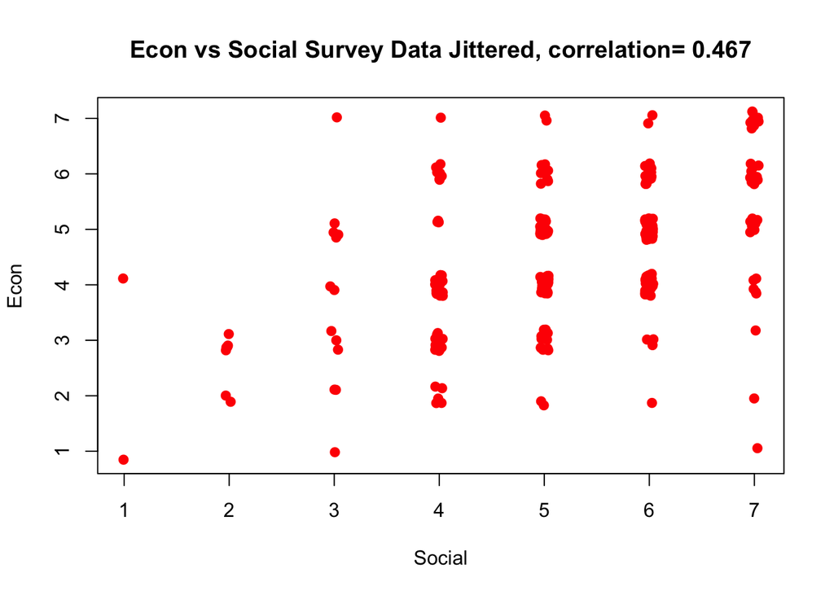

```r
# cleaning econ notice the same issues as before: only keep
# the first character, then convert to integer
cleanEcon <- substr(survey$Econ, 1, 1)
cleanEcon <- as.numeric(cleanEcon)

# pushing to data frame
survey$Social <- cleanSocial
survey$Econ <- cleanEcon

# out of curiosity: is social liberalness correlated with
# econ liberalness?  new data frame with social and econ
cleanSocialEcon <- cbind(cleanSocial, cleanEcon)
cleanSocialEcon <- na.omit(cleanSocialEcon)

# jittered since the same answers show up a lot
plot(jitter(cleanSocial, factor = 0.2), jitter(cleanEcon), pch = 19,
    col = "red", xlab = "Social", ylab = "Econ", main = paste("Econ vs Social Survey Data Jittered, correlation=",
        round(cor(cleanSocialEcon[, 1], cleanSocialEcon[, 2]),
            3)))
```

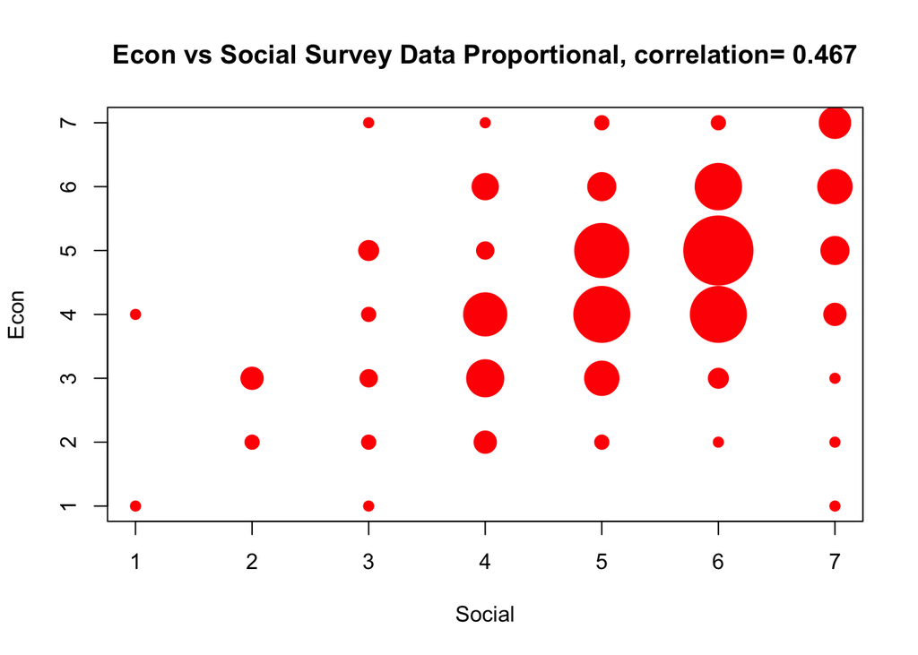

```r
# radii proportional to frequency to show in a different way
freq <- c(table(cleanSocialEcon[, 1], cleanSocialEcon[, 2]))
x1 <- rep(c(1:7), 7)
y1 <- sort(x1)
plot(x1, y1, pch = 19, col = "red", xlab = "Social", ylab = "Econ",
    cex = sqrt(freq), main = paste("Econ vs Social Survey Data Proportional, correlation=",
        round(cor(cleanSocialEcon[, 1], cleanSocialEcon[, 2]),
            3)))
```